# Exercise 8

Kyle M. Lang

Fundamental Techniques in Data Science with R

Much like last week, in this practical you will work through a relatively extensive analysis. This week, however, we will be working with logistic regression to analyze a binary outcome variable.

We will use the following packages:

```r
library(mice)
library(dplyr)
library(magrittr)
library(DAAG)
```

The following table shows the number of trials wherein different concentrations (`conc`) of the peptide-C protein inhibited the flow of current across a membrane. The `yes` column contains counts of trials wherein inhibition occurred.

| conc | no | yes |
| --- | --- | --- |
| 0.1 | 7 | 0 |
| 0.5 | 1 | 0 |
| 1.0 | 10 | 3 |
| 10.0 | 9 | 4 |
| 20.0 | 2 | 0 |
| 30.0 | 9 | 6 |
| 50.0 | 13 | 7 |
| 70.0 | 1 | 0 |
| 80.0 | 1 | 0 |
| 100.0 | 4 | 1 |
| 150.0 | 3 | 7 |

# 1 Working with Odds

## 1.1

**Create the above dataset as a data frame**

```r
data <- data.frame(conc = c(0.1, 0.5, 1, 10, 20, 30, 50, 70, 80, 100, 150),
                   no = c(7, 1, 10, 9, 2, 9, 13, 1, 1, 4, 3),
                   yes = c(0, 0, 3, 4, 0, 6, 7, 0, 0, 1 ,7)
                   )
data
```

## 1.2

**Add the following new variables to the dataset you created in 1.1**

- The total number of trials for each observation (i.e., the sum of the `no` and `yes` trials for each row)
- The proportion of `yes` trials in each row
- The log-odds of inhibition for each row (i.e., the log-odds of `yes` versus `no`)

```r
data <-
  data %>%
  mutate(total = no + yes,
         prop = yes / total,
         logit = qlogis(prop)
         )
```

The `qlogis()` function is equivalant to the log-odds (i.e, logit) function. See `?Logistic` for more information.

## 1.3

**Inspect the new columns**

Do you notice anything unusual?

```r
data
```

```
##     conc no yes total      prop      logit
## 1    0.1  7   0     7 0.0000000       -Inf
## 2    0.5  1   0     1 0.0000000       -Inf
## 3    1.0 10   3    13 0.2307692 -1.2039728
## 4   10.0  9   4    13 0.3076923 -0.8109302
## 5   20.0  2   0     2 0.0000000       -Inf
## 6   30.0  9   6    15 0.4000000 -0.4054651
## 7   50.0 13   7    20 0.3500000 -0.6190392
## 8   70.0  1   0     1 0.0000000       -Inf
## 9   80.0  1   0     1 0.0000000       -Inf
## 10 100.0  4   1     5 0.2000000 -1.3862944
## 11 150.0  3   7    10 0.7000000  0.8472979
```

There are many zero proportions which produce logit values of $-\infty$.

- We can work around this issue by adding a constant (usually 0.5) to all cells before calculating the log-odds.
- We add the same value to the numerator and denominator of our odds formula, so we don’t change the relative interpretations of the odds.

We could also add a 1 to each cell. This option is conceptually interesting because the log of 1 equals 0.

- It’s almost like we’re adding zero to the odds and still correcting the issue.

## 1.4

**Add a new column to your dataset containing the corrected log-odds**

Compute the value of this column using the following formulation of the log-odds:

$$\log(\text{odds}) = \log\left(\frac{\text{yes} + 0.5}{\text{no} + 0.5}\right)$$

```r
robustLogit <- function(x, y) log((x + 0.5) / (y + 0.5))

data <- data %>%
  mutate(logit2 = robustLogit(yes, no))

data
```

```
##     conc no yes total      prop      logit     logit2
## 1    0.1  7   0     7 0.0000000       -Inf -2.7080502
## 2    0.5  1   0     1 0.0000000       -Inf -1.0986123
## 3    1.0 10   3    13 0.2307692 -1.2039728 -1.0986123
## 4   10.0  9   4    13 0.3076923 -0.8109302 -0.7472144
## 5   20.0  2   0     2 0.0000000       -Inf -1.6094379
## 6   30.0  9   6    15 0.4000000 -0.4054651 -0.3794896
## 7   50.0 13   7    20 0.3500000 -0.6190392 -0.5877867
## 8   70.0  1   0     1 0.0000000       -Inf -1.0986123
## 9   80.0  1   0     1 0.0000000       -Inf -1.0986123
## 10 100.0  4   1     5 0.2000000 -1.3862944 -1.0986123
## 11 150.0  3   7    10 0.7000000  0.8472979  0.7621401
```

After calculating the logit using our robust formula, we don’t have any infinite logits.

# 2 Logistic Regression Modeling

## 2.1

**Fit a logistic regression model**

Use the `glm()` function to estimate a logistic regression model wherein:

- `prop` is the outcome
- `conc` is the only predictor
- The number of total trials per row are used as weights
  - We need to provide weights because a different number of trials can go into defining each observation of `prop`.

```r
fit <- glm(prop ~ conc, family = binomial, weights = total, data = data)
```

## 2.2

**Check the summary of the fitted model**

Interpret the slope estimate.

```r
summary(fit)
```

```
##
## Call:
## glm(formula = prop ~ conc, family = binomial, data = data, weights = total)
##
## Deviance Residuals:
##     Min       1Q   Median       3Q      Max
## -1.8159  -1.0552  -0.6878   0.3667   1.0315
##
## Coefficients:
##             Estimate Std. Error z value Pr(>|z|)
## (Intercept) -1.32701    0.33837  -3.922 8.79e-05 ***
## conc         0.01215    0.00496   2.450   0.0143 *
## ---
## Signif. codes:  0 '***' 0.001 '**' 0.01 '*' 0.05 '.' 0.1 ' ' 1
##
## (Dispersion parameter for binomial family taken to be 1)
##
##     Null deviance: 16.683  on 10  degrees of freedom
## Residual deviance: 10.389  on  9  degrees of freedom
## AIC: 30.988
##
## Number of Fisher Scoring iterations: 4
```

A unit increase in `conc` increases the log-odds of inhibition by 0.0122 units, and this increase is statistically significant.

If we exponentiate the slope estimate, we can get an interpretation in odds units, but the effect becomes multiplicative instead of additive.

- For every unit increase in `conc`, the odds of inhibition are 1.0122 times higher.

# 3 Model Diagnostics

As with the linear model, we can obtain a series of plots to help us inspect the assumptions of the logistic model.

## 3.1

**Generate diagnostic plots**

Use the `plot()` function to generate diagnostic plots for the model you estimated in 2.1.

- Inspect Plots 1 and 5
- What conclusions can you draw about your model?

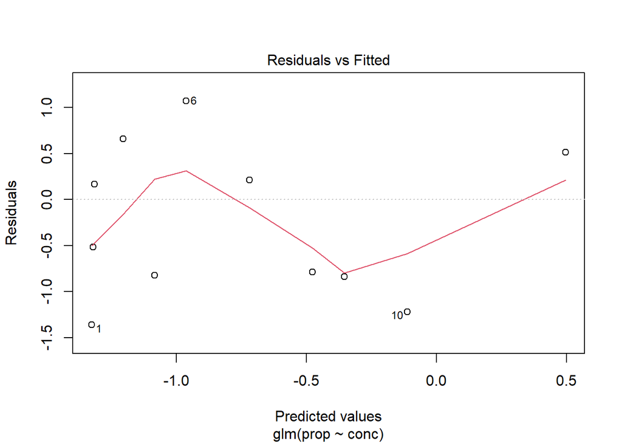

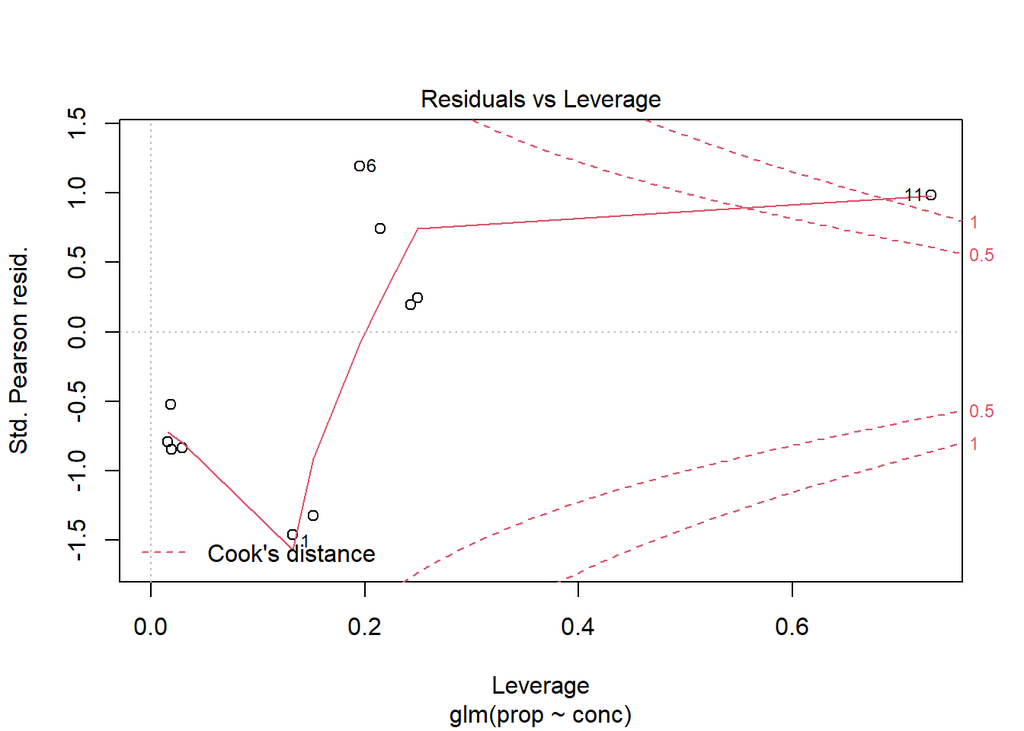

```r
plot(fit, which = c(1, 5))
```

The data set is very small, so there’s a lot of noise, and we need to be careful about placing too much faith in the estimates from this model. That being said, Case 11 stands out in the `Residuals vs. Leverage` plot; this case has quite a high leverage. Although Case 11’s residual is not extreme, its high leverage is sufficient to yield a Cook’s distance over 1.

# 4 Data Transformations

The model we estimated in 2.1 has only one predictor, so we know that the high leverage of Case 11 is due to a large value of `conc`.

```r
data.frame(conc = data$conc) %>% tail()
```

```
##    conc
## 6    30
## 7    50
## 8    70
## 9    80
## 10  100
## 11  150
```

If skewed variables or variables with a few extreme values are producing influential cases and adversely affecting our analysis, we can use data transformations to “pull-in” the extreme values.

- In particular, we want to transform the problematic variables with functions that have little effect on small values but substantially shrink large values.
  - The natural logarithm is a classic example.

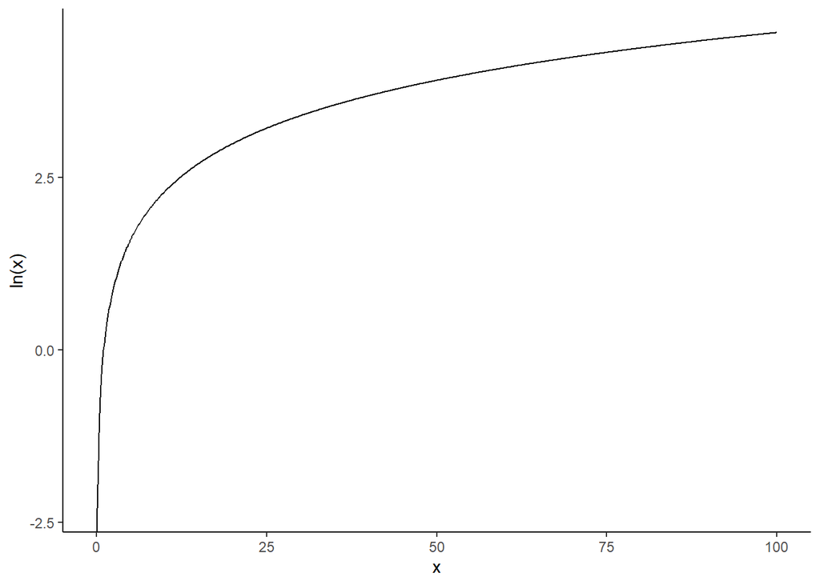

Notice the differential effect of applying the natural log to small versus large numbers:

| X | ln(X) |
| --- | --- |
| 1 | 0.000 |
| 2 | 0.693 |
| 3 | 1.099 |
| 5 | 1.609 |
| 10 | 2.303 |
| 50 | 3.912 |
| 100 | 4.605 |

The larger the value of a variable, the more the natural log function will shrink it.

- This property of the natural log makes it a great transformation for dealing with positively skewed variables.

### 4.0.1 Transformation Example

We can see a really clear effect of log-transformation by applying the natural log to the body weight variable (`bw`) from the `mice::mammalsleep` data set that we analyzed in the last practical.

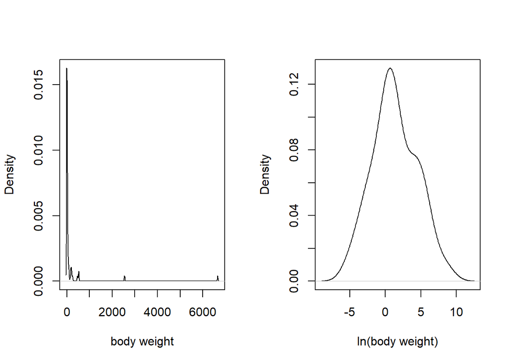

The extreme body weights of the two elephant species were severely skewing the raw data distribution, but the log-transformed version of body weight looks much better behaved.

## 4.1

**Visualize the effects of transforming `conc`**

Plot the density of the `conc` variable twice:

- Once with its original scaling
- Once after applying a log-tranformation

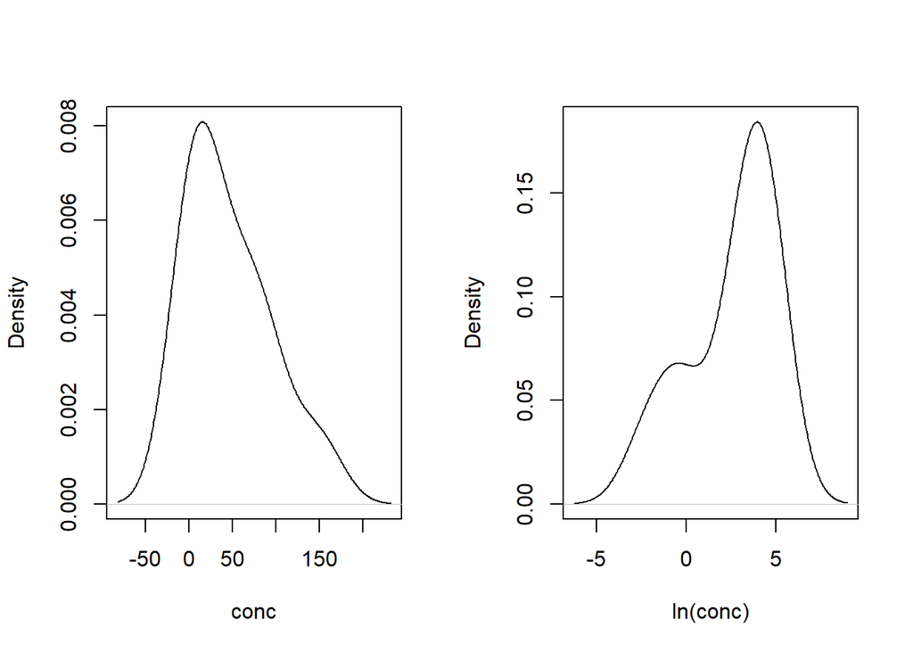

```r
par(mfrow = c(1, 2)) # Renders the plots side-by-side in one row

data$conc %>%
  density() %>%
  plot(main = "", xlab = "conc")

data$conc %>%
  log() %>%
  density() %>%
  plot(main = "", xlab = "ln(conc)")
```

- This reduction in range will help reduce the leverage of influential cases like Case 11.

# 5 Analyzing Transformed Data

## 5.1

**Estimate a logistic regression model with transformed data**

Use the `glm()` function to estimate a logistic regression model with the following characteristics:

- `prop` is the outcome
- The log-transformed version of `conc` is the only predictor
- The total number of trials per row are used as weights

To include the log-transformed predictor, we have two options.

1. We can create a new variable and use this transformed variable when estimating our model.
2. We can tell R to do the transformation for us by including special notation in the formula statement we supply to `glm()`.

The second appraoch is generally preferred unless you need the log-transformed variable for other visualizations/analyses.

```r
logFit <-
  glm(prop ~ I(log(conc)), family = binomial, weights = total, data = data)
```

Here, we’ve told R to do the transformation for us before estimating the model. To do so, we need to use the `I()` function to wrap the part of our formula that specifies the transformation.

- The `I()` function indicates that any interpretation and/or conversion of its argument should be inhibited and the argument should be evaluated ‘as is’.
  - We need to use `I()` here because `log(conc)` is valid, stand-alone R code. So, R will try to run `log(conc)` and throw any error, if we don’t use `I()`.
- Pretty much any time you are transforming a variable as part of a formula, you should warp the transformation in `I()`.

## 5.2

**Print the summary of the fitted model**

Interpret the slope estimate.

```r
summary(logFit)
```

```
##
## Call:
## glm(formula = prop ~ I(log(conc)), family = binomial, data = data,
##     weights = total)
##
## Deviance Residuals:
##     Min       1Q   Median       3Q      Max
## -1.2510  -1.0599  -0.5029   0.3152   1.3513
##
## Coefficients:
##              Estimate Std. Error z value Pr(>|z|)
## (Intercept)   -1.7659     0.5209  -3.390 0.000699 ***
## I(log(conc))   0.3437     0.1440   2.387 0.016975 *
## ---
## Signif. codes:  0 '***' 0.001 '**' 0.01 '*' 0.05 '.' 0.1 ' ' 1
##
## (Dispersion parameter for binomial family taken to be 1)
##
##     Null deviance: 16.6834  on 10  degrees of freedom
## Residual deviance:  9.3947  on  9  degrees of freedom
## AIC: 29.994
##
## Number of Fisher Scoring iterations: 4
```

The for a unit increase in the natural log of `conc`, the log-odds of inhibition increase by 0.344 units, and this increase is statistically significant.

After exponentiating the slope estimate, we would have the following interpretation. For every unit increase in the natural log of `conc`, the odds of inhibition are 1.41 time higher.

## 5.3

**Inspects the diagnostic plots**

Use the `plot()` function to generate diagnostic plots for the model you just estimated.

- Inspect Plot 1 and 5
- What conclusions can you draw from these plots?
- Was the transformation helpful?

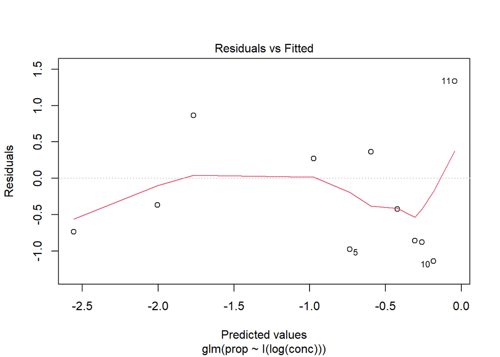

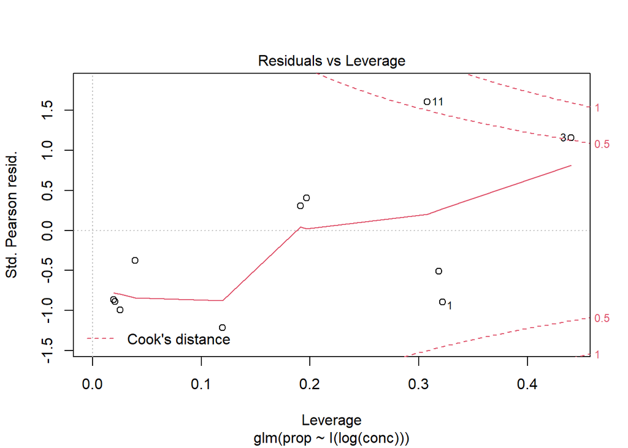

```r
plot(logFit, which = c(1, 5))
```

There are no more extremely influential cases. Case 11 has been pulled in toward the rest of the data and no longer exerts an undue influence on the model.

The transformation was helpful in that it produced a more stable model that is not affected by one overly influential observation.

- That being said, we don’t get this additional stability for free. We must interpret our slope estimate in units of `log(conc)` instead of raw `conc` units.

End of Exercise 8